# Assessing Success and Patient Experience in Assisted Reproductive Technology

Marc Rigas

### Overview

I have recently changed my final project in response to a discussion at a conference. The reason for the switch is the availability of a public data set that will allow for a new application of some of the data science techniques learned in this class. The new project is about assisted reproductive technologies. I spoke to about this project with Amy Branum, Chief of the Reproductive Statistics Branch at the National Center for Health Statistics, and a epidemiologist/nutritionist. I also spoke with a medical consumer behavior specialist at Kaiser Permanente, Dr. Sean Koons. Thirdly, I spoke with an MBA, process improvement specialist and founder of FertilityIQ, Jake Anderson. What I learned is that assisted reproductive technology is a complicated clinical service, because it is typically not paid by insurance; it involves a great deal of patient compliance and collaboration and is a highly emotional process for patients; thirdly, there is a lot of variability in success and perception for different clinics offering this service. The patient population is often highly educated and very invested in their own care. There is Federal data available that might show some interesting differences between clinics, but this data has not been well tapped.

Github Repository: https://github.com/rigasml/final_proj

### Introduction

In addition, there is, at least reported differences in success rates at different clinics. This leads some couples to be willing to travel across the country or across the world to get procedures done by a particular clinic. This is a very emotional process for women who engage in it, and women have been willing to provide a great deal of information on their experiences at the clinics and to disclose their personal medical information if it might help other patients in the future. The start up company, FertilityIQ has collected detailed survey information from more than 1,000 women who have undergone some type of ART procedure.

There is publicly available data on the ART clinics, this data is voluntarily submitted to the CDC as part of their annual survey on assisted reproductive technologies. Since the market is growing and this is becoming a more common elective procedure, with high emotional and financial costs for the couples who are using these services, it would be interesting to see what types of information on factors affecting success can be gleaned from the publicly available CDC data.

This is a multidisciplinary problem. It involves consumer behavior and sociology, endocrinology an reproductive medicine, and there is an aspect of process improvement (decision science and industrial engineering) for the clinics involved. It is expexted that down the road, analysis of this data can help women make smart decisions about their treatment and can help clinics improve their operations and have more unbiased information about patient behavior that might contribute to positive outcomes for the clinics and the patients.

### Methods

I am using the CDC 2013 Fertility Clinic Success Rate Data (http://www.cdc.gov/art/index.html) This dataset includes 213 variables collected from 468 reporting clinics in the United States. We will use Principal Components Analysis and use a general linear regression to explore which variables consistently have the largest impact on successful outcomes. The metric for a successful outcome in this analysis is “pregnancies per 100 transfers”. If it is possible to define a variable or set of variables on which success depends, then this will provide information for people using the CDC data set to choose clinics.

A second goal for this project will be to use publicly available social media data to try to get an initial impression of patient satisfaction with fertility clinics and IVF. I have searched the public two week Twitter feed on the words “fertility clinic” and “IVF”. I will present these early results in a qualitative manner using a word cloud.

A principal components analysis on the disease diagnosis variables was used to explore the greatest components of variability in disease diagnoses between the clinics.

```r
library(RCurl)
library(dplyr)
my.url <- getURL("https://raw.githubusercontent.com/rigasml/final_proj/master/NCHS_art2013.csv")
art2013.data <- read.csv(text = my.url, header=TRUE, sep=",",as.is=TRUE)

#count clinics by state
str(art2013.data)
```

```
## 'data.frame':    467 obs. of  213 variables:
##  $ OrderID                     : int  1 2 3 4 5 6 7 8 9 10 ...
##  $ PrevClinName1               : chr  "ALABAMA FERTILITY SPECIALISTS" "ART FERTILITY PROGRAM OF ALABAMA" "UNIVERSITY OF ALABAMA AT BIRMINGHAM" "HUNTSVILLE REPRODUCTIVE MEDICINE, PC" ...
##  $ PrevClinName2               : chr  "" "" "REPRODUCTIVE ENDOCRINOLOGY AND INFERTILITY" "" ...
##  $ ClinCityCode                : chr  "BIRMINGHAM" "BIRMINGHAM" "BIRMINGHAM" "HUNTSVILLE" ...
##  $ ClinStateCode               : chr  "ALABAMA" "ALABAMA" "ALABAMA" "ALABAMA" ...
##  $ IVF_Rate                    : chr  "100%" "100%" "100%" "100%" ...
##  $ ICSI_Rate                   : chr  "50%" "80%" "71%" "88%" ...
##  $ Unstimulated_Rate           : chr  "0%" "0%" "0%" "0%" ...
##  $ Gest_Rate                   : chr  "0%" "<1%" "1%" "<1%" ...
##  $ PGD_Rate                    : chr  "0%" "2%" "0%" "0%" ...
##  $ Diag_TubalRate              : chr  "27%" "29%" "24%" "29%" ...
##  $ Diag_OvulatoryRate          : chr  "40%" "17%" "9%" "23%" ...
##  $ Diag_DORRate                : chr  "15%" "18%" "39%" "39%" ...
##  $ Diag_EndometriosisRate      : chr  "23%" "29%" "16%" "17%" ...
```

[output cut: 86 more lines]

```r
StateCount <- art2013.data %>%
  group_by(ClinStateCode) %>%
  summarise(n=n())
arrange(StateCount, desc(n))
```

```
## Source: local data frame [51 x 2]
##
##     ClinStateCode     n
##             (chr) (int)
## 1      CALIFORNIA    68
## 2           TEXAS    43
## 3        NEW YORK    39
## 4         FLORIDA    30
## 5        ILLINOIS    26
## 6      NEW JERSEY    21
## 7    PENNSYLVANIA    19
## 8        VIRGINIA    13
## 9  NORTH CAROLINA    12
## 10           OHIO    12
## ..            ...   ...
```

```r
##California #1 with 6, then Texas.  PA #7 with 19.

##Statistics on clinics using gestational carrier (i.e. surrogate)
summary(art2013.data$Gest_Rate)
```

```
##    Length     Class      Mode
##       467 character character
```

```r
#Clean data - get rid of percent sign in number of variables of interest
art2013.data$Diag_ComboNoMaleRate <- as.numeric(sub("%", "", art2013.data$Diag_ComboNoMaleRate))
art2013.data$IVF_Rate <- as.numeric(sub("%", "", art2013.data$IVF_Rate))
art2013.data$Gest_Rate <- as.numeric(sub("%", "", art2013.data$Gest_Rate))
art2013.data$Diag_TubalRate <- as.numeric(sub("%", "", art2013.data$Diag_TubalRate))
art2013.data$Diag_OvulatoryRate <- as.numeric(sub("%", "", art2013.data$Diag_OvulatoryRate))
art2013.data$Diag_DORRate <- as.numeric(sub("%", "", art2013.data$Diag_DORRate))
art2013.data$Diag_EndometriosisRate <- as.numeric(sub("%", "", art2013.data$Diag_EndometriosisRate))
art2013.data$Diag_UterineRate <- as.numeric(sub("%", "", art2013.data$Diag_UterineRate))
#In previous steps, values labeled "<1%" get set to NA by coercion.  Set these values to zero

art2013.data$Diag_ComboNoMaleRate[is.na(art2013.data$Diag_ComboNoMaleRate)] <- 0
art2013.data$IVF_Rate[is.na(art2013.data$IVF_Rate)] <- 0
art2013.data$Gest_Rate[is.na(art2013.data$Gest_Rate)] <- 0
art2013.data$Diag_TubalRate[is.na(art2013.data$Diag_TubalRate)] <- 0
art2013.data$Diag_OvulatoryRate[is.na(art2013.data$Diag_OvulatoryRate)] <- 0
art2013.data$Diag_DORRate[is.na(art2013.data$Diag_DORRate)] <- 0
art2013.data$Diag_EndometriosisRate[is.na(art2013.data$Diag_EndometriosisRate)] <- 0
art2013.data$Diag_UterineRate[is.na(art2013.data$Diag_UterineRate)] <- 0



#Get these out of text form into numeric
art2013.data$FshNDEmbryosRate1 <- as.numeric(art2013.data$FshNDEmbryosRate1)
art2013.data$FshNDEmbryosRate2 <- as.numeric(art2013.data$FshNDEmbryosRate2)
art2013.data$FshNDEmbryosRate3 <- as.numeric(art2013.data$FshNDEmbryosRate3)
art2013.data$FshNDEmbryosRate4 <- as.numeric(art2013.data$FshNDEmbryosRate4)
art2013.data$FshNDEmbryosRate5 <- as.numeric(art2013.data$FshNDEmbryosRate5)
art2013.data$FshNDPregRate1
```

[output not shown]

[output cut: 52 more lines]

```r
art2013.data$FshNDPregRate1 <- as.numeric(art2013.data$FshNDPregRate1)
art2013.data$FshNDPregRate2 <- as.numeric(art2013.data$FshNDPregRate2)
art2013.data$FshNDPregRate3 <- as.numeric(art2013.data$FshNDPregRate3)
art2013.data$FshNDPregRate4 <- as.numeric(art2013.data$FshNDPregRate4)
art2013.data$FshNDPregRate5 <- as.numeric(art2013.data$FshNDPregRate5)
#Perform PCA on female disease diagnoses
art.pca <- prcomp(art2013.data[,11:15])

glm.diag <- glm(art2013.data$FshNDPregRate4 ~ art2013.data$Diag_TubalRate+art2013.data$Diag_DORRate+art2013.data$Diag_UterineRate+art2013.data$Diag_OvulatoryRate+art2013.data$Diag_EndometriosisRate)
cor(art2013.data$FshNDPregRate3, art2013.data$Diag_DORRate, use="complete.obs")
```

```
## [1] -0.01316936
```

```

```r
consumer_key <- REDACTED
consumer_secret <- REDACTED
access_token <- REDACTED
access_secret <- REDACTED
library(twitteR)
setup_twitter_oauth(consumer_key, consumer_secret, access_token, access_secret)
```

```
## [1] "Using direct authentication"
```

```r
library("wordcloud")
library("tm")
library("SnowballC")
library("RColorBrewer")
```

### Results

```r
summary(art2013.data$FshNDPregRate2)
```

```
##    Min. 1st Qu.  Median    Mean 3rd Qu.    Max.    NA's
##    4.50   30.15   37.00   37.43   44.65   76.70     204
```

It is staggering that families are willing to commit to rounds of ivf given the success rate of less than 50% and a cost of more that $10,000 per cycle. One can imagine very few medical procedures or consumer products, for that matter, where this cost and success rate would be considered acceptable. This is a further indication of the level of commitment and interest by the patient population.

```r
summary(art2013.data$IVF_Rate)
```

```
##    Min. 1st Qu.  Median    Mean 3rd Qu.    Max.
##    0.00  100.00  100.00   98.04  100.00  100.00
```

```r
summary(art2013.data$Gest_Rate)
```

```
##    Min. 1st Qu.  Median    Mean 3rd Qu.    Max.
##  0.0000  0.0000  0.0000  0.8887  1.0000 25.0000
```

A summary of the variables for IVF and for surrogacy indicates that almost all clinics do IVF in nearly 100% of the cases they report to CDC. However, surrogate parents are used 1% of the time or less. One clinic reported a 25% surrogacy (Gestational Carrier) rate. This clinic is in the Bay Area north of San Francisco and seems to get positive consumer reviews on the Internet. A point that was raised following the oral presentation is an interesting one. It is possible that this clinic serves a significant number of male same sex couples, leading to the high rate of surrogacy.

```r
summary(art.pca)
```

```
## Importance of components:
##                            PC1     PC2    PC3    PC4     PC5
## Standard deviation     16.6929 12.7951 9.7547 8.7166 7.37394
## Proportion of Variance  0.4172  0.2451 0.1425 0.1138 0.08141
## Cumulative Proportion   0.4172  0.6623 0.8048 0.9186 1.00000
```

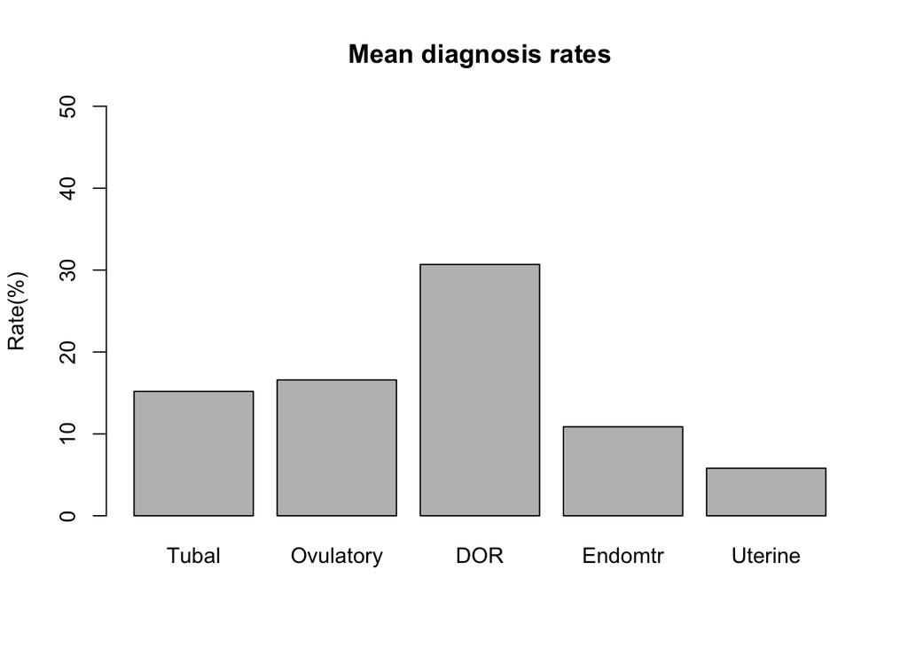

```r
barplot((sapply(art2013.data[,11:15], mean)),names.arg= c("Tubal","Ovulatory","DOR","Endomtr","Uterine"), ylim=c(0,50),ylab="Rate(%)", main="Mean diagnosis rates")
```

The plot of mean diagnosis rates across clinics indicates that these are two moderately common disease diagnoses (the most common is Diminished Ovarian Reserve (DOR), with a mean diagnosis rate of more than 30%).

```r
summary(glm.diag)
```

```
##
## Call:
## glm(formula = art2013.data$FshNDPregRate4 ~ art2013.data$Diag_TubalRate +
##     art2013.data$Diag_DORRate + art2013.data$Diag_UterineRate +
##     art2013.data$Diag_OvulatoryRate + art2013.data$Diag_EndometriosisRate)
##
## Deviance Residuals:
##      Min        1Q    Median        3Q       Max
## -18.9395   -6.2460    0.2098    4.8014   29.2074
##
## Coefficients:
##                                     Estimate Std. Error t value Pr(>|t|)
## (Intercept)                         21.07001    2.76174   7.629 7.47e-12
## art2013.data$Diag_TubalRate         -0.02561    0.14861  -0.172    0.863
## art2013.data$Diag_DORRate           -0.02731    0.05461  -0.500    0.618
## art2013.data$Diag_UterineRate        0.05315    0.20322   0.262    0.794
## art2013.data$Diag_OvulatoryRate     -0.17832    0.13233  -1.348    0.180
## art2013.data$Diag_EndometriosisRate  0.17725    0.13385   1.324    0.188
##
## (Intercept)                         ***
## art2013.data$Diag_TubalRate
## art2013.data$Diag_DORRate
## art2013.data$Diag_UterineRate
## art2013.data$Diag_OvulatoryRate
## art2013.data$Diag_EndometriosisRate
## ---
## Signif. codes:  0 '***' 0.001 '**' 0.01 '*' 0.05 '.' 0.1 ' ' 1
##
## (Dispersion parameter for gaussian family taken to be 78.18359)
##
##     Null deviance: 9276.9  on 120  degrees of freedom
## Residual deviance: 8991.1  on 115  degrees of freedom
##   (346 observations deleted due to missingness)
## AIC: 878.68
##
## Number of Fisher Scoring iterations: 2
```

```r
summary(art2013.data$FshNDPregRate3)
```

```
##    Min. 1st Qu.  Median    Mean 3rd Qu.    Max.    NA's
##    4.20   22.80   28.00   29.06   35.05   66.70     236
```

```r
summary(art2013.data$FshNDPregRate2)
```

```
##    Min. 1st Qu.  Median    Mean 3rd Qu.    Max.    NA's
##    4.50   30.15   37.00   37.43   44.65   76.70     204
```

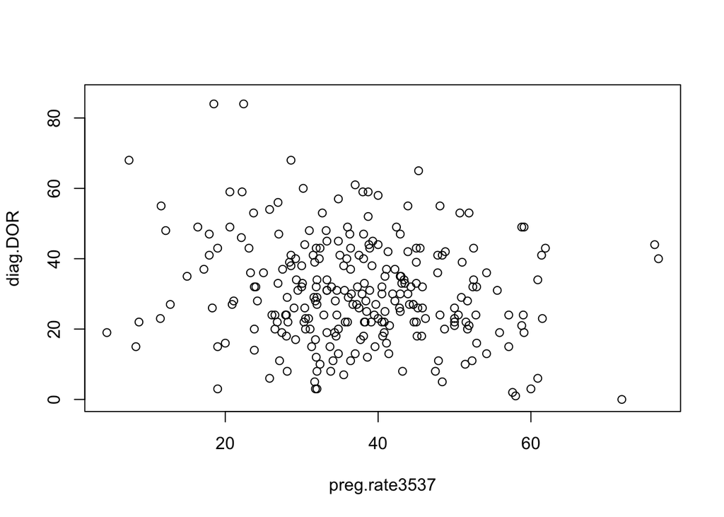

```r
preg.rate3537 <- art2013.data$FshNDPregRate2
diag.DOR <- art2013.data$Diag_DORRate
plot(preg.rate3537,diag.DOR)
```

# Word cloud of Tweets for ‘fertility’

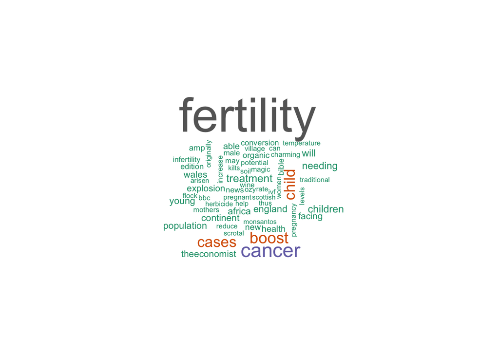

```r
tweets <- searchTwitter('fertility', n=2000)
tweet_text <- sapply(tweets, function(x) x$getText()) #convert list entries to text
tweet_text_corpus <- Corpus(VectorSource(tweet_text)) #create corpus
#Change encoding of text to avoid errors
tweet_text_corpus <- tm_map(tweet_text_corpus,
                              content_transformer(function(x) iconv(x, to='UTF-8-MAC', sub='byte'))
)

#clean up - all lower case, remove urls, no punctuation, remove stopwords
#can use inspect(tweet_text_corpus) along the way to look at contents


tweet_text_corpus <- tm_map(tweet_text_corpus, content_transformer(tolower))
tweet_text_corpus <- tm_map(tweet_text_corpus, removePunctuation)
tweet_text_corpus <- tm_map(tweet_text_corpus, removeNumbers)
removeURL <- function(x) gsub("http[[:alnum:]]*", "", x)
tweet_text_corpus <- tm_map(tweet_text_corpus, content_transformer(removeURL))
myStopwords <- c(stopwords(), "via")
tweet_text_corpus <- tm_map(tweet_text_corpus, function(x) removeWords(x, myStopwords))

wc.fertility <- wordcloud(tweet_text_corpus, min.freq=20, max.words=60, random.order=T, colors=brewer.pal(8, "Dark2"))
```

# Wordcloud for ‘ivf’

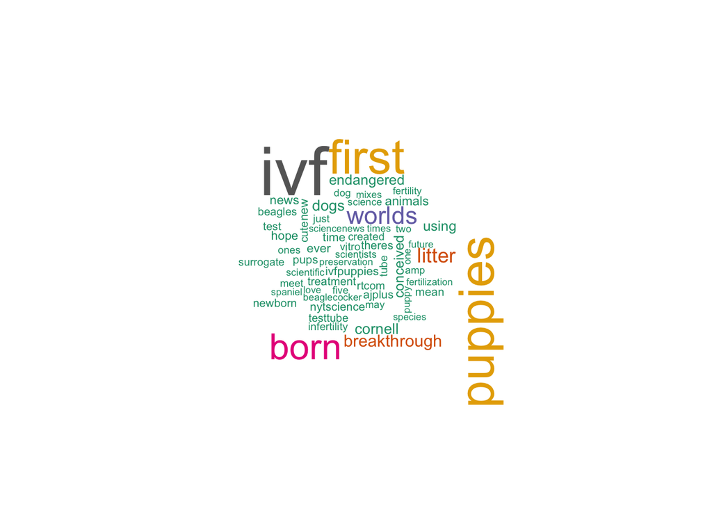

```r
tweets <- searchTwitter('ivf', n=2000)
tweet_text <- sapply(tweets, function(x) x$getText()) #convert list entries to text
tweet_text_corpus <- Corpus(VectorSource(tweet_text)) #create corpus
#Change encoding of text to avoid errors
tweet_text_corpus <- tm_map(tweet_text_corpus,
                              content_transformer(function(x) iconv(x, to='UTF-8-MAC', sub='byte'))
)
#clean up - all lower case, remove urls, no punctuation, remove stopwords
#can use inspect(tweet_text_corpus) along the way to look at contents
tweet_text_corpus <- tm_map(tweet_text_corpus, content_transformer(tolower))
tweet_text_corpus <- tm_map(tweet_text_corpus, removePunctuation)
tweet_text_corpus <- tm_map(tweet_text_corpus, removeNumbers)
removeURL <- function(x) gsub("http[[:alnum:]]*", "", x)
tweet_text_corpus <- tm_map(tweet_text_corpus, content_transformer(removeURL))
myStopwords <- c(stopwords(), "via")
tweet_text_corpus <- tm_map(tweet_text_corpus, function(x) removeWords(x, myStopwords))

wc.ivf <- wordcloud(tweet_text_corpus, min.freq=10, max.words=60, random.order=T, colors=brewer.pal(8, "Dark2"))
```

# Wordcloud for ‘ivf clinic’

```r
tweets <- searchTwitter('ivf clinic', n=2000)
```

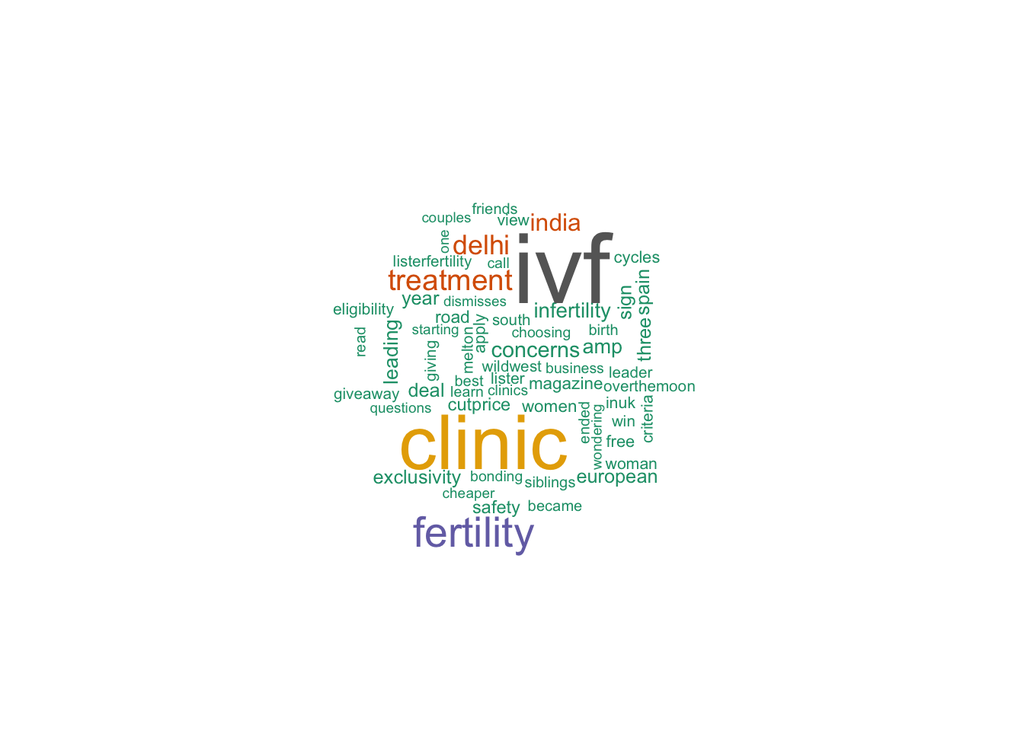

```r
tweet_text <- sapply(tweets, function(x) x$getText()) #convert list entries to text
tweet_text_corpus <- Corpus(VectorSource(tweet_text)) #create corpus
#Change encoding of text to avoid errors
tweet_text_corpus <- tm_map(tweet_text_corpus,
                              content_transformer(function(x) iconv(x, to='UTF-8-MAC', sub='byte'))
)
#clean up - all lower case, remove urls, no punctuation, remove stopwords
#can use inspect(tweet_text_corpus) along the way to look at contents
tweet_text_corpus <- tm_map(tweet_text_corpus, content_transformer(tolower))
tweet_text_corpus <- tm_map(tweet_text_corpus, removePunctuation)
tweet_text_corpus <- tm_map(tweet_text_corpus, removeNumbers)
removeURL <- function(x) gsub("http[[:alnum:]]*", "", x)
tweet_text_corpus <- tm_map(tweet_text_corpus, content_transformer(removeURL))
myStopwords <- c(stopwords(), "via")
tweet_text_corpus <- tm_map(tweet_text_corpus, function(x) removeWords(x, myStopwords))

wordcloud(tweet_text_corpus, min.freq=2, max.words=60, random.order=T, colors=brewer.pal(8, "Dark2"))
```

As the Twitter search pulls the preceding two weeks of data, it appears to be extremely sensitive to timing of the search. I ran one search for the oral presentation. I just knitted this written presentation for final submission and the Twitter Word Cloud has changed substantially. This means Twitter is very good for detecting current and trending events. The text below refers to the word clouds generated for the oral presentation. That search returned high frequency results on china, probably due to news events at the time about ivf clinics in China at the end of the Chinese one child policy. In the current search on “ivf clinic”, “India” was returned with a higher frequency.

The Twitter search returned some moderate support for the notion that people struggle with fertility, and more specifically, with their ivf clinic experience.

The original questions were how much can be assessed from publicly available data to help patients differentiate between fertility clinics and the conditions that may either be correlated with or lead to successful pregnancy. IVF is a complicated process and people come to clinics for a variety of reasons, including medical conditions. The process requires a high degree of patient involvement, decision making, and compliance. The best clinics, no doubt, are trusted partners in this process. The reported CDC data makes it challenging for people to make simple comparisons, to the extent that simple comparisons can even be made. There are data quality and availability issues, but it is quite likely that the task of comparing the complicated processes leading to success would be nearly impossible from any similar data set.

The Twitter data is highly sensitive to trending current events. The Twitter feed appears to be mildly to moderately suggestive that there is stress around this procedure, around infertility, around struggles with ivf, and perhaps even with low cost medical tourism for these treatments.

Further meta analyses on the health conditions around infertility and their relationship to success in the clinical ivf procedures may be possible using proprietary data collected by the professional society, Society of Assisted Reproductive Technologies (SART). These datasets are available with permission of SART, but a research proposal must be submitted. This leads to other questions of how open the organization is to data sharing if the research proposed would not be seen as acceptable by the Society. A start-up company, Fertility IQ has collected voluntary survey data from over 1,000 patients. This survey data is quite detailed but is also proprietary. It will be interesting to explore how this medical practice develops in the upcoming years as procedures likely continue to improve and more couples of all types are choosing to use these services.